# G4_Tarek Oueidat_Makram Noureddine

The goal of this work is to identify if a certain employee will get promoted or not based on a set of attributes provided.

Multiple attributes have been provided around Employee's past and current performance along with demographics.

```python
import pandas as pd
import numpy as np
import matplotlib.pyplot as plt
import seaborn as sns
from sklearn.model_selection import train_test_split
%matplotlib inline
```

```python
promo = pd.read_csv('C:/Users/Makram/Desktop/MSBA 315/hr analytics/hr analytics/HR_promotion.csv')
```

# DATA EXPLORATION

```python
promo.head()
```

|  | employee_id | department | region | education | gender | recruitment_channel | no_of_trainings | age | previous_year_rating | length_of_service | awards_won? | avg_training_score | is_promoted |
| --- | --- | --- | --- | --- | --- | --- | --- | --- | --- | --- | --- | --- | --- |
| 0 | 65438 | Sales & Marketing | region_7 | Master's & above | f | sourcing | 1 | 35 | 5.0 | 8 | 0 | 49 | 0 |
| 1 | 65141 | Operations | region_22 | Bachelor's | m | other | 1 | 30 | 5.0 | 4 | 0 | 60 | 0 |
| 2 | 7513 | Sales & Marketing | region_19 | Bachelor's | m | sourcing | 1 | 34 | 3.0 | 7 | 0 | 50 | 0 |
| 3 | 2542 | Sales & Marketing | region_23 | Bachelor's | m | other | 2 | 39 | 1.0 | 10 | 0 | 50 | 0 |
| 4 | 48945 | Technology | region_26 | Bachelor's | m | other | 1 | 45 | 3.0 | 2 | 0 | 73 | 0 |

```python
promo.columns
```

```
Index(['employee_id', 'department', 'region', 'education', 'gender',
       'recruitment_channel', 'no_of_trainings', 'age', 'previous_year_rating',
       'length_of_service', 'awards_won?', 'avg_training_score',
       'is_promoted'],
      dtype='object')
```

```python
promo.info()
```

```
<class 'pandas.core.frame.DataFrame'>
RangeIndex: 54808 entries, 0 to 54807
Data columns (total 13 columns):
 #   Column                Non-Null Count  Dtype
---  ------                --------------  -----
 0   employee_id           54808 non-null  int64
 1   department            54808 non-null  object
 2   region                54808 non-null  object
 3   education             52399 non-null  object
 4   gender                54808 non-null  object
 5   recruitment_channel   54808 non-null  object
 6   no_of_trainings       54808 non-null  int64
 7   age                   54808 non-null  int64
 8   previous_year_rating  50684 non-null  float64
 9   length_of_service     54808 non-null  int64
 10  awards_won?           54808 non-null  int64
 11  avg_training_score    54808 non-null  int64
 12  is_promoted           54808 non-null  int64
dtypes: float64(1), int64(7), object(5)
memory usage: 5.4+ MB
```

```python
for column in promo.columns:
    if promo[column].dtype == object:
        print(str(column)+' : '+str(promo[column].unique()))
        print(promo[column].value_counts())
        print('________________________________________________________________________')
```

```
department : ['Sales & Marketing' 'Operations' 'Technology' 'Analytics' 'R&D'
 'Procurement' 'Finance' 'HR' 'Legal']
Sales & Marketing    16840
Operations           11348
Technology            7138
Procurement           7138
Analytics             5352
Finance               2536
HR                    2418
Legal                 1039
R&D                    999
Name: department, dtype: int64
________________________________________________________________________
region : ['region_7' 'region_22' 'region_19' 'region_23' 'region_26' 'region_2'
 'region_20' 'region_34' 'region_1' 'region_4' 'region_29' 'region_31'
 'region_15' 'region_14' 'region_11' 'region_5' 'region_28' 'region_17'
 'region_13' 'region_16' 'region_25' 'region_10' 'region_27' 'region_30'
 'region_12' 'region_21' 'region_8' 'region_32' 'region_6' 'region_33'
 'region_24' 'region_3' 'region_9' 'region_18']
region_2     12343
region_22     6428
region_7      4843
region_15     2808
region_13     2648
region_26     2260
region_31     1935
region_4      1703
region_27     1659
region_16     1465
region_28     1318
region_11     1315
region_23     1175
region_29      994
region_32      945
region_19      874
region_20      850
region_14      827
region_25      819
region_17      796
region_5       766
```

[output cut: 17 more lines]

```
Master's & above    14925
Below Secondary       805
Name: education, dtype: int64
________________________________________________________________________
gender : ['f' 'm']
m    38496
f    16312
Name: gender, dtype: int64
________________________________________________________________________
recruitment_channel : ['sourcing' 'other' 'referred']
other       30446
sourcing    23220
referred     1142
Name: recruitment_channel, dtype: int64
________________________________________________________________________
```

Since the employee ID doens't have any useful information and since we don't have any background about the regions references and what each region means, we will drop these column moving forward so we can have only the info that can be interpreted and explained.

```python
promo = promo.drop(['employee_id','region'], axis=1)
```

```python
promo.info()
```

```
<class 'pandas.core.frame.DataFrame'>
RangeIndex: 54808 entries, 0 to 54807
Data columns (total 11 columns):
 #   Column                Non-Null Count  Dtype
---  ------                --------------  -----
 0   department            54808 non-null  object
 1   education             52399 non-null  object
 2   gender                54808 non-null  object
 3   recruitment_channel   54808 non-null  object
 4   no_of_trainings       54808 non-null  int64
 5   age                   54808 non-null  int64
 6   previous_year_rating  50684 non-null  float64
 7   length_of_service     54808 non-null  int64
 8   awards_won?           54808 non-null  int64
 9   avg_training_score    54808 non-null  int64
 10  is_promoted           54808 non-null  int64
dtypes: float64(1), int64(6), object(4)
memory usage: 4.6+ MB
```

Now we will plot a histogram to see how the numerical data is distributed

```
array([[<matplotlib.axes._subplots.AxesSubplot object at 0x0000018C2BFE1400>,
      dtype=object)
```

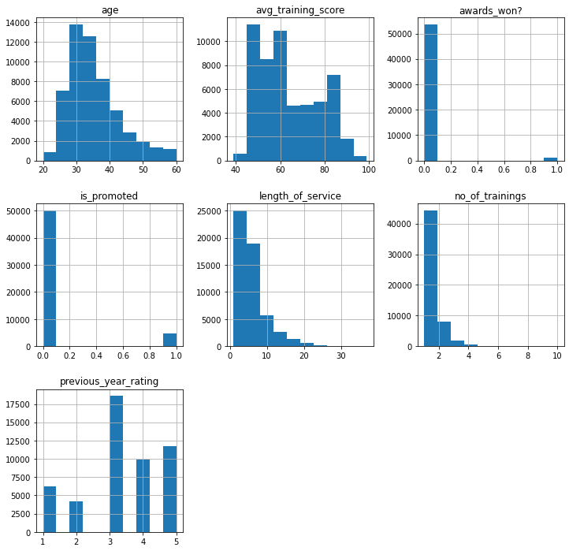

```python
promo.hist(figsize=(12,12))
```

Looking at the above graphs, it's clear that the numerical features are skewed and hence data normalization is required later on

It is to be noted that in the awards won column, the output is binary where 1 means that an employee has won an award and 0 means hasn't won anything. For that we will convert the awards won column into a categorical column of yes and no.

```python
promo['awards_won?'].value_counts()
```

```
0    53538
1     1270
Name: awards_won?, dtype: int64
```

```python
promo['awards_won?'] = promo['awards_won?'].map({1:'yes', 0: 'no'})
```

```python
promo.department = promo.department.astype('category')
promo['awards_won?'] = promo['awards_won?'].astype('category')
promo.education = promo.education.astype('category')
promo.gender = promo.gender.astype('category')
promo.recruitment_channel = promo.recruitment_channel.astype('category')
promo.age = promo.age.astype('int64')
```

```python
assert promo.department.dtype == 'category'
assert promo['awards_won?'].dtype == 'category'
assert promo.education.dtype == 'category'
assert promo.gender.dtype == 'category'
assert promo.recruitment_channel.dtype == 'category'
assert promo.age.dtype == 'int64'
```

```python
promo.info()
```

```
<class 'pandas.core.frame.DataFrame'>
RangeIndex: 54808 entries, 0 to 54807
Data columns (total 11 columns):
 #   Column                Non-Null Count  Dtype
---  ------                --------------  -----
 0   department            54808 non-null  category
 1   education             52399 non-null  category
 2   gender                54808 non-null  category
 3   recruitment_channel   54808 non-null  category
 4   no_of_trainings       54808 non-null  int64
 5   age                   54808 non-null  int64
 6   previous_year_rating  50684 non-null  float64
 7   length_of_service     54808 non-null  int64
 8   awards_won?           54808 non-null  category
 9   avg_training_score    54808 non-null  int64
 10  is_promoted           54808 non-null  int64
dtypes: category(5), float64(1), int64(5)
memory usage: 2.8 MB
```

Now that we made sure that all our features are of numerical and categorical type, we will proceed further on with some deep data exploration.

First we will start by checking where we have null values across the columns

```python
promo.isna().sum()
```

```
department                 0
education               2409
gender                     0
recruitment_channel        0
no_of_trainings            0
age                        0
previous_year_rating    4124
length_of_service          0
awards_won?                0
avg_training_score         0
is_promoted                0
dtype: int64
```

We only have some missing data across the eductaion column and the previous year rating column.

For the education column which is of type categorical, we will create during the scope of our work an imputer function which replaces the NA values by a constant.

As for the previous year rating which is of type numerical, we will create anythor imputer which repalces the NA values with the median value.